- **Title: Real data CAPE Positive**
- **Output: html_document**
- **Reference: A guide to test association between Polygenic Risk Scores and psychological and psychiatric traits: practical examples**
- **Authors: Itziar Irigoien, Patricia Mas, Sergi Papiol, Neus Barrantes-Vidal, Araceli Rosa, and Concepción Arenas**

## Real data CAPE Positive as binary Trait

- **In this real data set there are 106 PRS, and a binary Trait ($CAPE_{Positive}$), with gender, age, and two Principal Components as covariates.**
- **Data reading**

```r
dat <- read.table("Real_data_Positive.csv", header=TRUE, sep="\t", dec=".")
names(dat) #
```

```
##   [1] "ID"            "Sex"           "Age"           "CAPE_Positive"
##   [5] "PRS.1"         "PRS.2"         "PRS.3"         "PRS.4"
##   [9] "PRS.5"         "PRS.6"         "PRS.7"         "PRS.8"
##  [13] "PRS.9"         "PRS.10"        "PRS.11"        "PRS.12"
##  [17] "PRS.13"        "PRS.14"        "PRS.15"        "PRS.16"
##  [21] "PRS.17"        "PRS.18"        "PRS.19"        "PRS.20"
##  [25] "PRS.21"        "PRS.22"        "PRS.23"        "PRS.24"
##  [29] "PRS.25"        "PRS.26"        "PRS.27"        "PRS.28"
##  [33] "PRS.29"        "PRS.30"        "PRS.31"        "PRS.32"
##  [37] "PRS.33"        "PRS.34"        "PRS.35"        "PRS.36"
##  [41] "PRS.37"        "PRS.38"        "PRS.39"        "PRS.40"
##  [45] "PRS.41"        "PRS.42"        "PRS.43"        "PRS.44"
##  [49] "PRS.45"        "PRS.46"        "PRS.47"        "PRS.48"
##  [53] "PRS.49"        "PRS.50"        "PRS.51"        "PRS.52"
##  [57] "PRS.53"        "PRS.54"        "PRS.55"        "PRS.56"
##  [61] "PRS.57"        "PRS.58"        "PRS.59"        "PRS.60"
##  [65] "PRS.61"        "PRS.62"        "PRS.63"        "PRS.64"
##  [69] "PRS.65"        "PRS.66"        "PRS.67"        "PRS.68"
##  [73] "PRS.69"        "PRS.70"        "PRS.71"        "PRS.72"
##  [77] "PRS.73"        "PRS.74"        "PRS.75"        "PRS.76"
##  [81] "PRS.77"        "PRS.78"        "PRS.79"        "PRS.80"
##  [85] "PRS.81"        "PRS.82"        "PRS.83"        "PRS.84"
##  [89] "PRS.85"        "PRS.86"        "PRS.87"        "PRS.88"
##  [93] "PRS.89"        "PRS.90"        "PRS.91"        "PRS.92"
##  [97] "PRS.93"        "PRS.94"        "PRS.95"        "PRS.96"
## [101] "PRS.97"        "PRS.98"        "PRS.99"        "PRS.100"
## [105] "PRS.101"       "PRS.102"       "PRS.103"       "PRS.104"
## [109] "PRS.105"       "PRS.106"       "PC1"           "PC2"
```

```r
dat <- dat[, -1]
```

- **Check that all variables you are interested in are properly read and that there are not other variables you do not need.**
- **Do not forget to declare the categorical variables as factors**

```r
dat$Sex <- as.factor(dat$Sex)
dat$CAPE_Positive <- as.factor(dat$CAPE_Positive)
```

## 1. What full model should be considered?

- **First, given a particular PRS (named PRS.i), consider all the possible full models:**
- **FMW I : log(p/1-p) versus PRS.i + Sex + Age + PC1 + PC2**
- **FMSex: log(p/1-p) versus PRS.i + Sex + PRS.i,Sex + Age + PC1 + PC2**

## 2. How to make a PRS ranking to find the important ones?

- **As is described in the paper, for each model, calculate the Tjur’s coefficients of discrimination. If Nagelkerke’s $R^2$ is prefered, set statistic=“PseudoR2” in function orderBin(), and calculate their sum $S$.**
- **According to S, list the PRSs in decreasing order:**

```r
# Order the PRSs
out <- orderBin(dat, yname="CAPE_Positive", prsname = "PRS.", statistic = "D")
head(out)
```

```
##            Model1     Model2        Sum
## PRS.15 0.03458250 0.06713832 0.10172083
## PRS.16 0.03662211 0.06247882 0.09910094
## PRS.14 0.02913388 0.06465976 0.09379364
## PRS.11 0.02658133 0.06369724 0.09027858
## PRS.12 0.02415016 0.06359970 0.08774985
## PRS.10 0.02603126 0.06110069 0.08713195
```

```r
mainfilename <- "Real_data_CAPE_Positive"
filename <- paste0(mainfilename, "_Ordered_PRS.csv")
write.csv2(out,file=filename)
```

- **Plot the sum of discrimination coefficients $D$. Lines: in blue the median; in black the mean.**

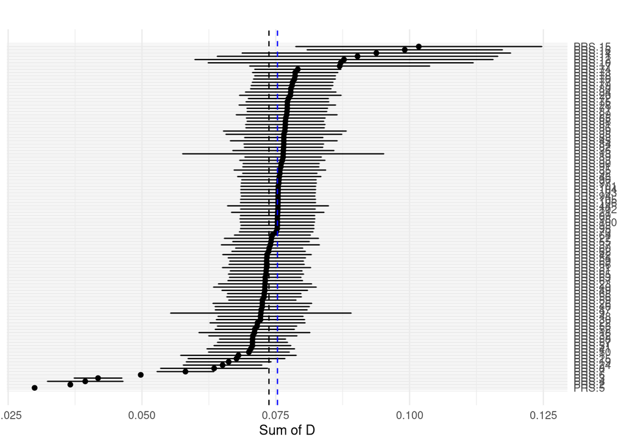

```r
out <- data.frame(out)
n <- dim(out)[1]
select <- grep("Model", names(out), value=FALSE)
out$effect <- out$Sum
sds <- apply(out[, select], 1, sd)
out$lower <- out$effect - sds
out$upper <- out$effect + sds
out$rank <- n:1


ggplot(data=out, aes(y=rank, x=effect, xmin=lower, xmax=upper)) +
  geom_point() +
  geom_errorbarh(height=.1) +
  scale_y_continuous(name=NULL, breaks= n:1, labels=row.names(out), position="right") +
  labs(title='', x='Sum of D', y = 'PRS') +
  geom_vline(xintercept=mean(out$effect), color='black', linetype='dashed') +
  geom_vline(xintercept=median(out$effect), color='blue', linetype='dashed') +
  theme_minimal()
```

- **According to the obtained results, first PRS.15 is selected to analyse its association with the $CAPE_{Positive}$.**

### 3. Which model, of all the possible ones, should be used?

- **The following Figure represents the scatter plot separated by Sex group.**

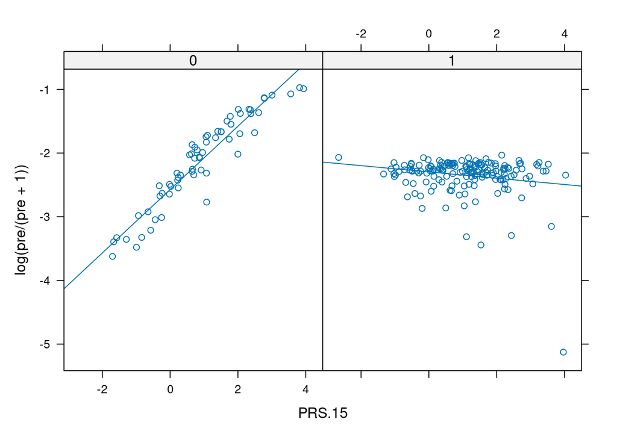

```r
# First candidate PRS.15
# Plot it
M <- glm(CAPE_Positive ~ PRS.15*Sex + Age + PC1 + PC2, data=dat, family=binomial())
pre <- M$fitted.values #predict(M,type='response')
xyplot(log(pre/(pre+1))~PRS.15|Sex, data=dat,  type=c("p", "r"))
```

- **The plots suggest that the interaction between the PRS.15 and the diagnostic is relevant. Thus, we set the full model candidate (FM): $CAPE_{Positive} \sim PRS + Sex + PRS\cdot Sex + Age + PC1 +PC2$**

### 5. For a binary trait, what steps should be followed for a correct analysis?

- **Check for overdispersion**

```r
#model
FM <- glm(CAPE_Positive ~ Sex + PRS.15*Sex + Age + PC1 + PC2, data=dat, family=binomial())
#Residual Deviance
FM$deviance
```

```
## [1] 165.7134
```

```r
# Ratio
FM$deviance/FM$df.residual
```

```
## [1] 0.7532427
```

- **Since this ratio is close to 1, there is not evidence of overdispersion.**

```r
#With chi-squared test
FM.od <- glm(CAPE_Positive ~ Sex + PRS.15*Sex + Age + PC1 + PC2, data=dat, family=quasibinomial())
pchisq(summary(FM.od)$dispersion * FM$df.residual,
       FM$df.residual, lower = F)
```

```
## [1] 0.2651312
```

- **With this p-value = 0.2651 we conclude that there is not evedence of overdispersion.**
- **Based on the estimations given in this table:**

```r
summary(FM)
```

```
##
## Call:
## glm(formula = CAPE_Positive ~ Sex + PRS.15 * Sex + Age + PC1 +
##     PC2, family = binomial(), data = dat)
##
## Coefficients:
##             Estimate Std. Error z value Pr(>|z|)
## (Intercept)  0.05492    2.22416   0.025   0.9803
## Sex1         0.13895    0.66711   0.208   0.8350
## PRS.15       0.74628    0.28997   2.574   0.0101 *
## Age         -0.11833    0.10697  -1.106   0.2686
## PC1          1.95129   14.54023   0.134   0.8932
## PC2          2.86709   14.94056   0.192   0.8478
## Sex1:PRS.15 -0.74871    0.35877  -2.087   0.0369 *
## ---
## Signif. codes:  0 '***' 0.001 '**' 0.01 '*' 0.05 '.' 0.1 ' ' 1
##
## (Dispersion parameter for binomial family taken to be 1)
##
##     Null deviance: 177.27  on 226  degrees of freedom
## Residual deviance: 165.71  on 220  degrees of freedom
## AIC: 179.71
##
## Number of Fisher Scoring iterations: 5
```

- **The PRS.15 coefficient will vary depending on the gender, being:**
  - $\widehat{log(p/1-p)} = 0.055 + 0.746\times PRS.15 - 0.118\times Age + 1.951\times PC1 + 2.867\times PC2$, if Sex = 0.
  - $\widehat{log(p/1-p)} = (0.055 + 0.139) + (0.746 - 0.749)\times PRS.15 - 0.118\times Age + 1.951\times PC1 + 2.867\times PC2$, if Sex = 1.
- **Check whether the respective PRS coefficients under each group are significant or not.**

```r
summary(glht(FM, "PRS.15 = 0"))
```

```
##
##   Simultaneous Tests for General Linear Hypotheses
##
## Fit: glm(formula = CAPE_Positive ~ Sex + PRS.15 * Sex + Age + PC1 +
##     PC2, family = binomial(), data = dat)
##
## Linear Hypotheses:
##             Estimate Std. Error z value Pr(>|z|)
## PRS.15 == 0   0.7463     0.2900   2.574   0.0101 *
## ---
## Signif. codes:  0 '***' 0.001 '**' 0.01 '*' 0.05 '.' 0.1 ' ' 1
## (Adjusted p values reported -- single-step method)
```

```r
summary(glht(FM, "PRS.15  + Sex1:PRS.15 = 0"))
```

```
##
##   Simultaneous Tests for General Linear Hypotheses
##
## Fit: glm(formula = CAPE_Positive ~ Sex + PRS.15 * Sex + Age + PC1 +
##     PC2, family = binomial(), data = dat)
##
## Linear Hypotheses:
##                            Estimate Std. Error z value Pr(>|z|)
## PRS.15 + Sex1:PRS.15 == 0 -0.002425   0.211998  -0.011    0.991
## (Adjusted p values reported -- single-step method)
```

```r
# Null model
NM <- glm(CAPE_Positive ~  Sex + Age + PC1 + PC2, data=dat, family=binomial() )
permtest <- dD(NM, FM, seed=1236)
permtest
```

```
## $dD
##          1
## 0.05246593
##
## $pvalue
## [1] 0.008
```

- **In this particular case, it can be seen that the coefficient of discrimination of the FM model is 0.05 units bigger than the corresponding to the *Null Model* NM, and it is statistically significant.**
- **Last step: We move to the next PRS.**